# Förutsättningar för ekonomisk tillväxt Magnus Forslund, analytiker

## Bakgrund

Rapporten ingår som ett underlag i ett arbete med att studera hur förutsättningarna för ekonomisk tillväxt ser ut i Västmanlands län och dess kommuner. En grundfråga är hur utvecklingen av bruttoregionprodukten (BRP) har sett ut och hur den förhåller sig till såväl rikets nivå (BNP) som jämförbara regioner i landet. Genom att studera ett antal olika delar som påverkar den ekonomiska utvecklingen försöker vi ge en bild av om utvecklingen i länet är i nivå med vad som kan förväntas och vilka skillnader och utmaningar som finns inom länet.

Inledningsvis beskrivs utvecklingen av BRP och tillväxtens beståndsdelar, sysselsättning och produktivitet. Därefter går vi igenom länets demografiska och geografiska förutsättningar, hur befolkningssammansättningen och arbetskraftsdeltagandet ser ut och hur det skiljer sig åt mellan länets kommuner. Vi tittar på utbildningsnivån i länet och hur möjligheter till matchning ser ut för kompetensförsörjningen. Ett avsnitt tar upp arbetsmarknadens struktur sett till branscher och specialisering samt hur olika näringsgrenar bidrar till BRP. Vi tittar på det internationella utbytet för länets företag, dels sett till varuexport och -import och dels till vilka andra beroenden som finns i länet. Avslutningsvis tar vi upp olika hinder för tillväxt, som de beskrivs av företagen själva.

Rapporten avslutas med en utblick mot hur de bakomliggande faktorerna påverkar ett antal tillväxtkomponenter som offentliga aktörer på olika sätt och i skiftande utsträckning har möjlighet att påverka.

## Bruttonationalprodukt, BNP

Ekonomisk tillväxt är den relativa ökningen av värdet på ett samhälles produktion av varor och tjänster enligt bruttonationalprodukten (BNP) jämfört med föregående tidsperiod (månad, kvartal eller år).

Ungefär 80 procent av BNP:s värde kommer från privata företag och 20 procent kommer från den offentliga sektorn. Den offentliga sektorns del av BNP är till exempel tjänster inom polisen, försvaret, vården och skolan.

Produktionen i privata företag delas upp i varor och tjänster. Tjänsterna står för knappt 70 procent och varorna för drygt 30 procent.

## Bruttoregionprodukt, BRP

Bruttoregionprodukten (BRP) mäter utvecklingen för mindre områden, vanligen län men även för kommuner. Summan av länens BRP motsvarar landets bruttonationalprodukt. I Västmanland kommer en något större del av den privata produktionen från varor än i riket, drygt 40 procent. Tjänster motsvarar alltså knappt 60 procent av den privata produktionen i länet.

Utvecklingen av BRP kan mätas på olika sätt, nedan ses utvecklingen i löpande respektive fasta priser (2015 års priser). Löpande priser uttrycker det nominella värdet som inte är rensat för värdeförändringar på grund av inflation. Fasta priser uttrycker det reala värdet, som alltså är värdet i en annan periods priser. Som ett trendmått är därför fasta priser att föredra då det kan sägas ge en sannare bild av utvecklingen.

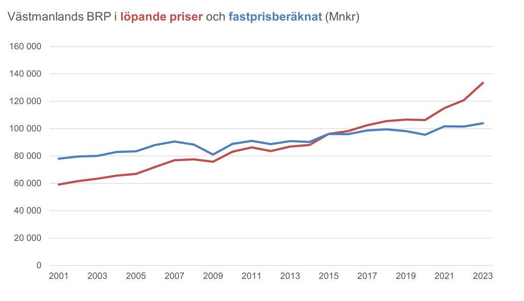

Källa: SCB och egen beräkning av fast pris. Basår 2015

Utvecklingen kan också mätas som den årliga volymutvecklingen i procent. Som diagrammet visar har den årliga förändringen av BRP för Västmanland pendlat en del under hela 2000-talet. År 2021 ökade BRP med närmare 7 procent, vilket var något över riksgenomsnittet. Därefter var förändringen under 0 år 2022 för att sedan åter stiga till drygt två procent år 2023. Nedgången 2020 var betingad av pandemin medan länets nedgång år 2019 egentligen är den tydligaste avvikelsen från rikskurvan under hela perioden. Även 2023 innebar som vi ser en mer positiv utveckling i länet än i riket, sannolikt åstadkommen genom sysselsättningsökning i kombination med att tillverkningsindustrin gick bra.

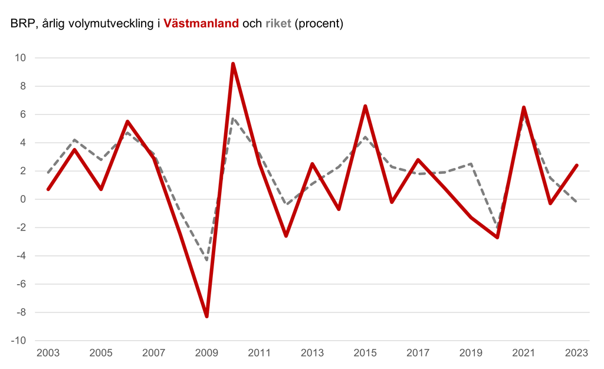

Källa: SCB

## Tillväxtens beståndsdelar

Ekonomisk tillväxt genereras enkelt uttryckt på tre sätt, genom:

- att fler personer arbetar
- att varje person arbetar fler timmar
- att det produceras mer under varje arbetad timme

Här har vi alltså två övergripande mått på sysselsättning och ett mått för produktivitet. Vi kommer att titta närmare på måtten samt föra en diskussion om de olika förutsättningar som finns för vart och ett av dem.

### Sysselsättning

Sedan något år går det att följa utvecklingen av sysselsättningen via Befolkningens arbetsmarknadsstatus (BAS) på ett sätt som inte tidigare varit möjligt. Statistik över antal sysselsatta kan nu tas fram på månadsbasis med bara några månaders eftersläpning och fördelat på olika bakgrundsvariabler som kommun, kön, ålder och svensk/utländsk bakgrund. BAS bygger på registerbaserade data, uppgifterna är dock preliminära under innevarande år och definitiva helårsuppgifter publiceras med ungefär ett års eftersläpning, precis som med den registerbaserade arbetsmarknadsstatistiken (RAMS), som BAS ersätter från och med år 2022.

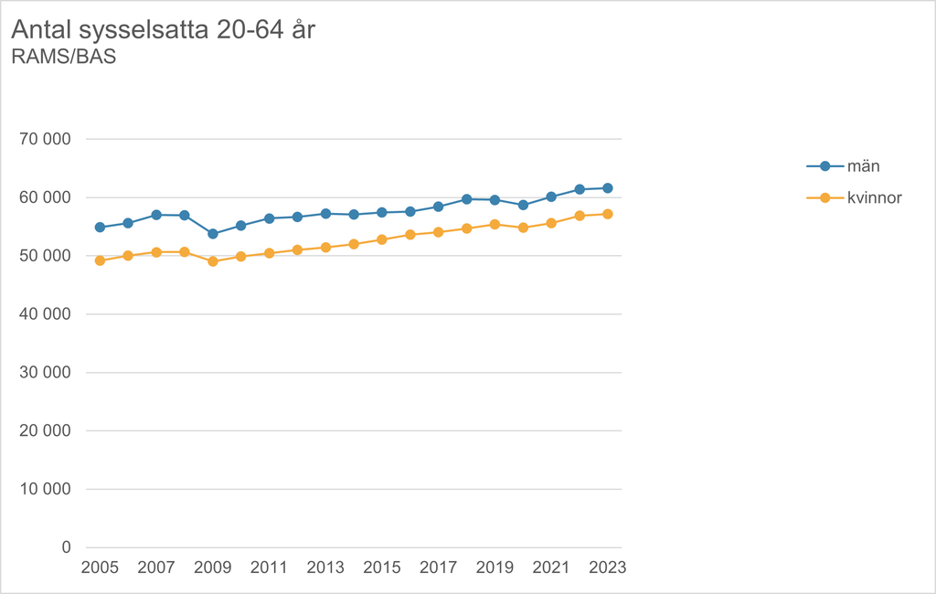

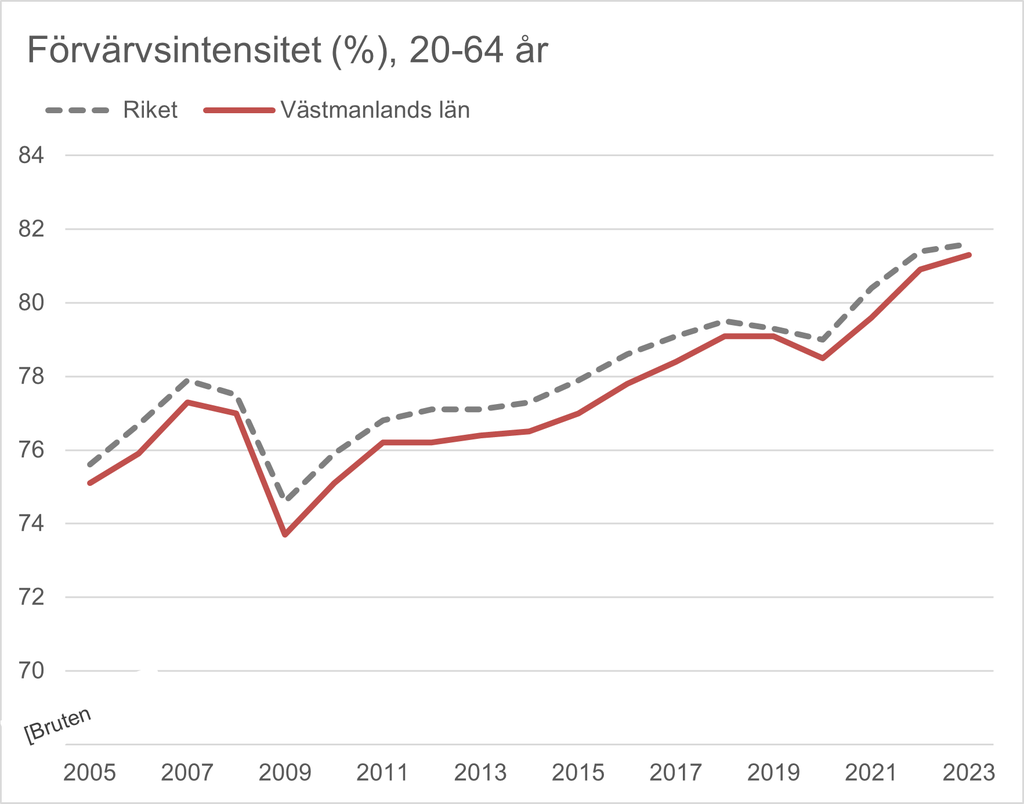

Förvärvsintensiteten i både länet och riket är alltså högre än på mycket länge och en viktig anledning är att den har ökat tydligt bland utrikes födda. År 2022 var gruppens förvärvsintensitet ca 70 %, vilket motsvarar en uppgång med sex procentenheter sedan år 2020 och 15 procentenheter sedan år 2010. Gruppen sverigefödda hade 85 % förvärvsintensitet år 2022, en ökning med 1,5 procentenheter mellan år 2020-2022 och med fem procentenheter jämfört med år 2010. Sannolikt är det en kombination av förändrade attityder, förändrade rekryteringsprocesser och bättre matchningsprocesser som ligger bakom utvecklingen. En annan viktig aspekt är att förvärvsintensiten bland sverigefödda nu är så pass hög att ytterligare ökningar blir svårare att uppnå. Antalet personer i Västmanland som varit inskrivna vid arbetsförmedlingen längre än ett år var ca 4 500 personer i maj 2024. Av dessa räknades 4 000 personer till gruppen utsatta med svag konkurrensförmåga på arbetsmarknaden. Även inom den gruppen har antalet dock minskat, i samband med pandemin i mitten av 2021 bestod den av ca 5 700 personer.

### Produktivitet

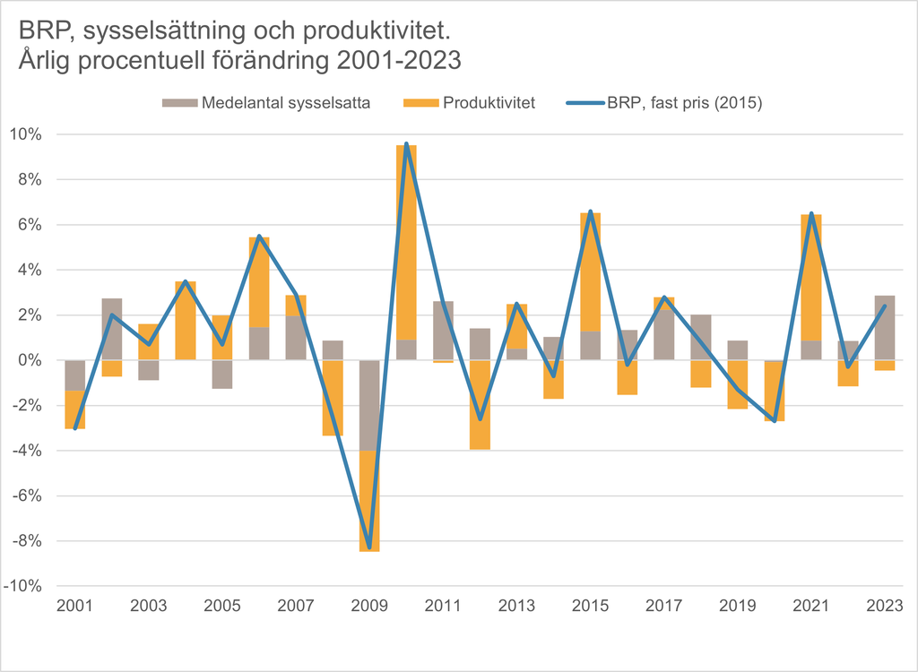

### BRP per sysselsatt

I metoden som beskrivits ovan motsvaras produktiviteten av BRP per sysselsatt uttryckt i fasta priser. Som ett ytterligare förtydligande redovisas utvecklingen för BRP/sysselsatta under 2000-talet i löpande respektive fasta priser. Uttryckt i fasta priser blir det tydligt att produktiviteten i länet inte har förändrats nämnvärt sedan år 2010.

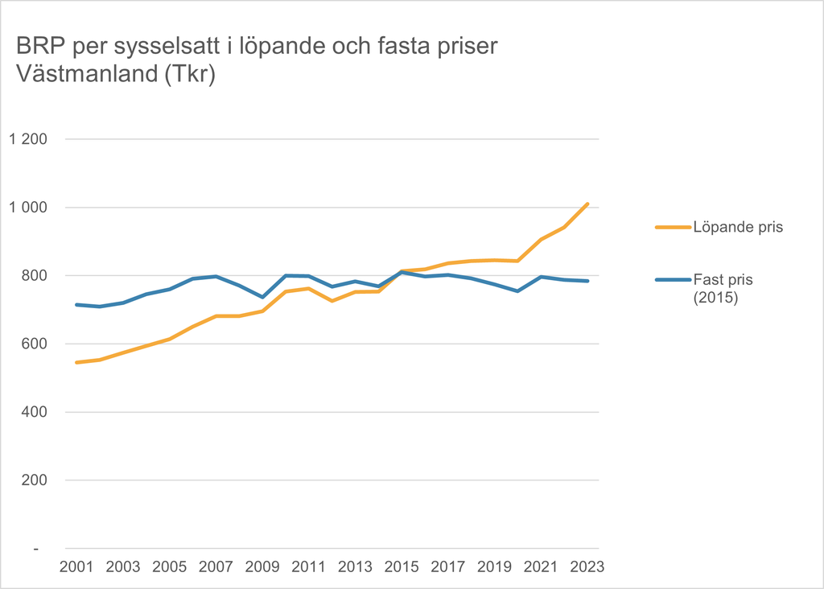

## Demografiska förutsättningar

Befolkningens sammansättning i ett område förändras gradvis och på olika sätt. Människor föds, dör och åldras däremellan alternativt flyttar in eller ut från/till antingen andra länder eller andra delar av Sverige. Ur ett ekonomiskt tillväxtperspektiv läggs fokus ofta på åldersgruppen i den arbetsföra åldern, 20-64 år. Det i sin tur är ett begrepp som möjligen behöver omprövas och ses på nya sätt. Dels skjuts ofta inträdet på arbetsmarknaden fram i takt med att allt fler genomgår högre utbildning och dels arbetar allt fler längre än tidigare. Pensionsåldern flyttades fram ett år från och med 2023 till 65 år, men det är inte ovanligt att arbeta längre än så. De sista åren på arbetsmarknaden kan dock ofta innebära en nedgång i faktisk arbetad tid. Ett nytt begrepp och mått som därför blivit vanligare är “kärnarbetskraften”, som avser personer i åldern 25-54 år. Det blir ett sätt att se hur dynamiken ser ut bland hela den sysselsatta befolkningen, genom att se hur den utvecklas i tre olika åldersgrupper, 15-24 år, 25-54 år samt 55-74 år.

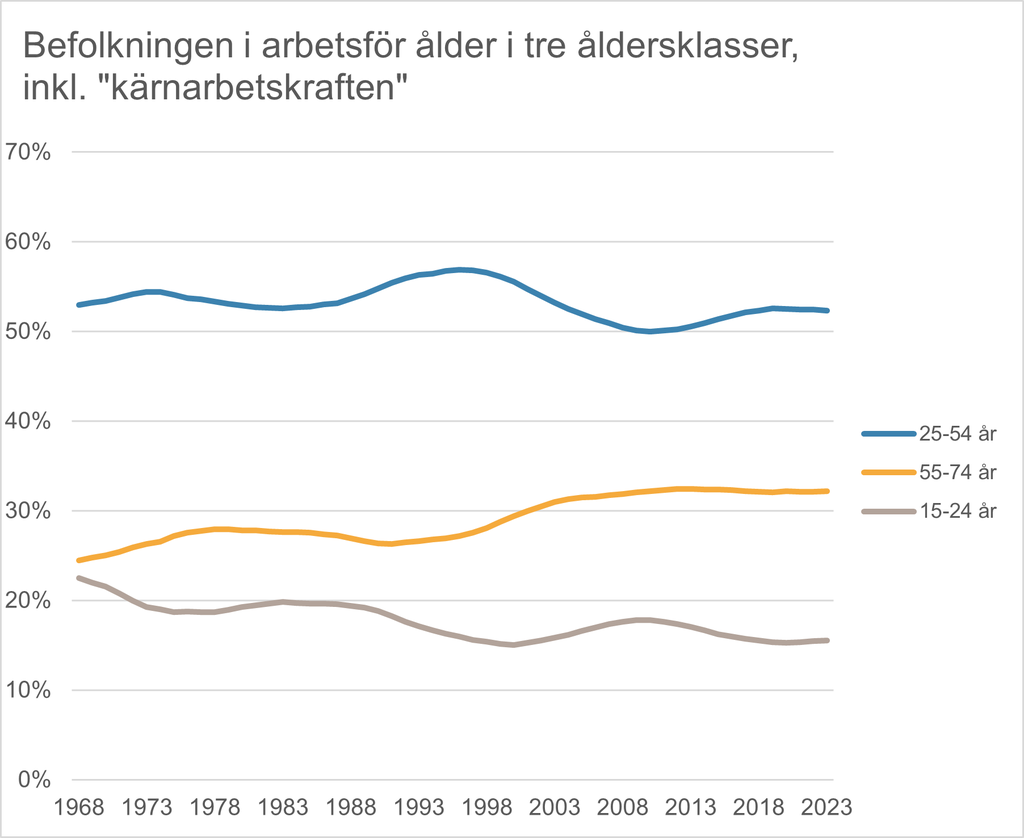

Andel av samtliga i åldern 15-74 år (oavsett sysselsättning).

### Demografisk försörjningskvot

Demografisk försörjningskvot är ett mått som visar hur många personer det finns utanför den arbetsföra befolkningen jämfört med personer som är i arbetsför ålder, 20-64 år. Försörjningskvoten beräknas som summan av antalet personer utanför arbetsför ålder (0-19 år respektive 65 år och äldre) dividerat med antal personer 20-64 år och därefter multiplicerat med hundra. Ett värde över 100 betyder alltså att det finns fler personer utanför arbetsför ålder än i den samma. Den demografiska försörjningskvoten har stigit relativt tydligt i Västmanland sedan år 2010 och var 82 vid publiceringen av den senaste befolkningsstatistiken, år 2023. I bilden nedan visas utvecklingen från 1968 och fram till 2023. Därefter visas förhållandet i den senaste befolkningsframskrivningen från SCB från år 2024. Fram till år 2050 förväntas alltså kvoten stiga ytterligare.

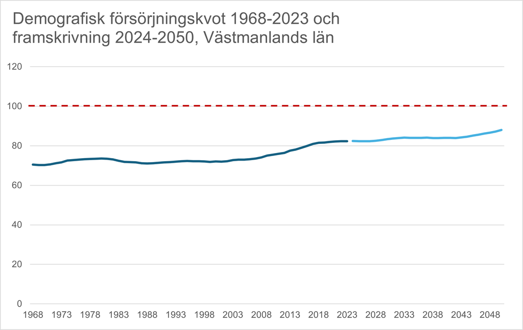

Bilden över de demografiska förutsättningarna i länet skyms dock något av att Västerås har en relativt låg demografisk försörjningskvot. Om vi plockar bort Västerås från den tidigare bilden och istället visar hur det ser ut i länets övriga nio kommuner hamnar den demografiska försörjningskvoten betydligt närmare 100 redan kring år 2030. De kommuner som har den äldsta befolkningen i länet, Skinnskatteberg och Norberg, är i princip där redan idag.

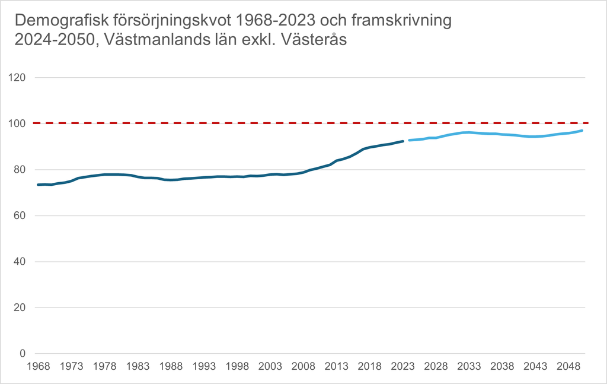

## Geografiska förutsättningar

Länets geografi har en relativt tydlig uppdelning mellan de södra, mer befolkningstäta delarna och de norra delarna av länet, där antalet orter är färre med längre avstånd mellan orterna som konsekvens. Det medför också att bebyggelsestrukturen skiljer sig åt mellan länets olika delar. Slutligen påverkas utvecklingen av vilka relationer och resmönster som finns mellan orter i Västmanland och i angränsande län. I Sala blickar man naturligt åt öster med Heby och Uppsala; i Fagersta, Norberg och Skinnskatteberg finns ett utbytt mellan främst kommuner i södra Dalarna; Arboga är strategiskt beläget mellan Västerås och Örebro och har starka band åt båda hållen; Kungsör slutligen har en fysisk närhet till Eskilstuna sm underlättar arbetspendling och bosättningsmöjligheter.

Utvecklingen de senaste 20 åren har inneburit en allt tydligare koncentration av befolkningen till urbana områden eller rurala områden i dess absoluta närhet. Under 2000-talet har folkmängden utanför tätort eller småort minskat med tre procent i länet. Folkmängden i tätorter har ökat med 15 procent under samma period. Här finns den största tillväxten sett till antal personer, ca 32 500 av den totala ökningen på ca 33 900 personer mellan åren 2000-2020. Folkmängden i småorter har ökat mest procentuellt under 2000-talet, 62 procent. Det gäller främst småorter i södra delen av länet och motsvarar ca 2 200 personer.

Kartan visar den övergripande befolkningsutvecklingen mellan åren 2013 och 2023 i länets tätorter. Storleken på punkterna motsvarar en klassificering som gjorts i olika ortsklasser, där till exempel Västerås utgör en egen klass och länets övriga centralorter en annan. Färgen på punkterna visar om tätorten haft en positiv, negativ eller oförändrad befolkningsutveckling de senaste tio åren.

[figure not shown]

Gränserna mellan nivåerna för befolkningsförändringen går från -25 % till -3,5 % (minskat), -2,5 % till 2,8 % (oförändrat) och 5 % till 100 % (ökat). Källa: Region Västmanland

## Infrastruktur, tillgänglighet och hur det påverkar bostadsmarknaden

Den föregående kartbilden visar ett län som är relativt tydligt uppdelat mellan flera urbana centran i södra länet (inklusive den närliggande landsbygden) och den norra delen av länet, med Fagersta som huvudsaklig arbetsort. Den norra länsdelen är viktig för länets historia, gemensamma värderingar och historiska grundförutsättningar i form av råvaror och tillverkningsindustri. Här grundlades länets framväxt som industriellt område samtidigt som vi under många år har sett vikande siffror för både befolkning och arbetstillfällen. För att inte uppdelningen som kartan och statistiken visar ska fortsätta utvecklas åt olika håll behöver vi hitta olika sätt att tydligare knyta ihop länsdelarna.

### Förändringar på bostadsmarknaden

Det finns ett tydligt samband mellan avståndet/restiden till Västerås (och andra större städer i Mälardalen) och det sk. Tobins q-måttet, som anger om det ekonomiskt lönsamt att bygga nya bostäder i ett område. I den studie som Region Västmanland tog fram i början av 2023 såg vi tydliga indikationer på att den positiva utveckling vi sett för Tobins q i de flesta av länets kommuner ganska snabbt avtog när det stod klart att bostadsmarknaden stod inför stora utmaningar. Det var relativt tidigt i konjunkturnedgången och innan det kraftiga inflationstrycket fått riktigt genomslag och inte minst skulle komma att påverka försäljningspriser för småhus och bostadsrätter. Det finns alltså all anledning att tro att siffrorna skulle vara betydligt mindre positiva om studien återupprepades idag. Tobins q beräknas genom att dividera försäljningspriser med produktionskostnader och det som hänt är att försäljningspriserna har sjunkit samtidigt som produktionskostnaderna har ökat. Huvudtanken med studien var dock att kunna påvisa hur regionala insatser i infrastrukturen på längre sikt påverkar tillgängligheten till den lokala arbetsmarknaden, som i Västmanlands fall omfattar hela länet. På sikt antar vi därför att scenariot ligger fast, men med möjliga mindre förskjutningar i såväl nivå som i tid.

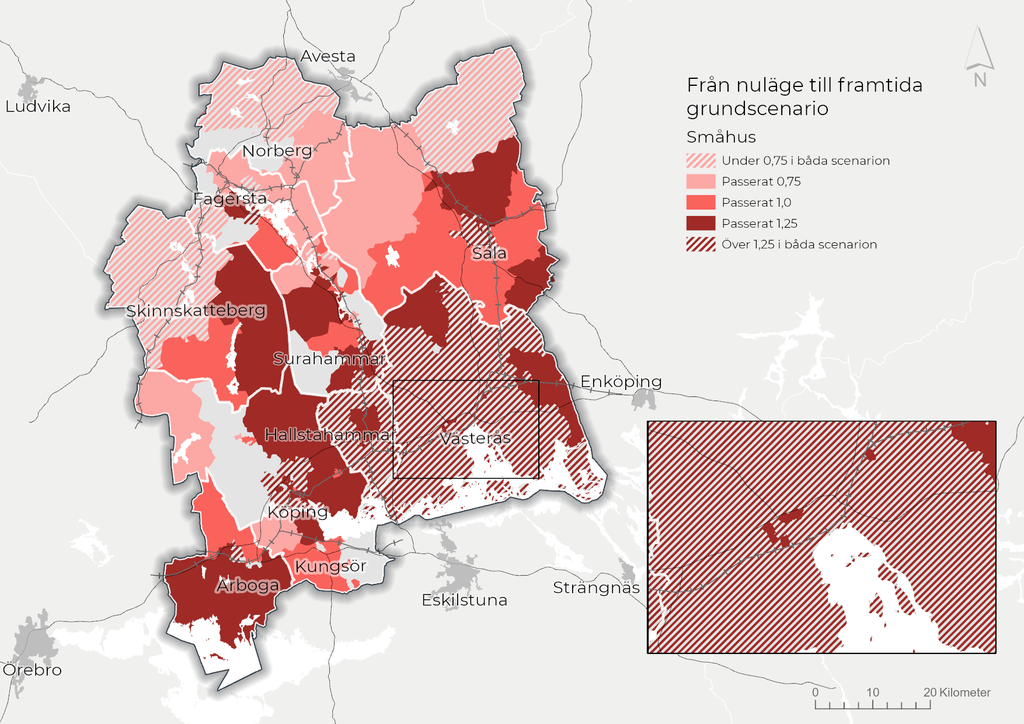

Slutsatsen blir att den lokala arbetsmarknadens betydelse för hur bostadsmarknaden i stort utvecklas inte kan underskattas. Oavsett färdmedel så behöver restiden ner på rimliga nivåer för att det ska få positiva effekter på sikt i form av befolkningstillväxt och investeringsvilja. Här behövs kanske också ett mer uppdaterat sätt att se på även bostadsmarknaden som en större helhet i länet än vad kommungränserna anger.

### Tillgänglighet till lokal arbetsmarknad

Kartbilden till vänster visar tillgängligheten till arbetsställen med bil och kollektivtrafik i nuläget (år 2022) för människor efter var de bor i länet. Ju mörkare färg i kartan, desto fler arbetsställen kan nås inom en rimlig restid. Den högra kartan visar hur ett scenario ser ut, där de insatser som beskrivs i den aktuella Länstransportplanen (tillsammans med planerade nationella satsningar) har genomförts. Som vi ser så påverkas såväl de delar av länet som redan har en hög tillgänglighet såväl som de delar där tillgängligheten idag är relativt låg. Framförallt bildas en form av korridor längs Bergslagsbanan (inklusive Fagersta tätort) där tillgängligheten ökar, men även i länets sydvästra delar ökar tillgängligheten relativt tydligt.

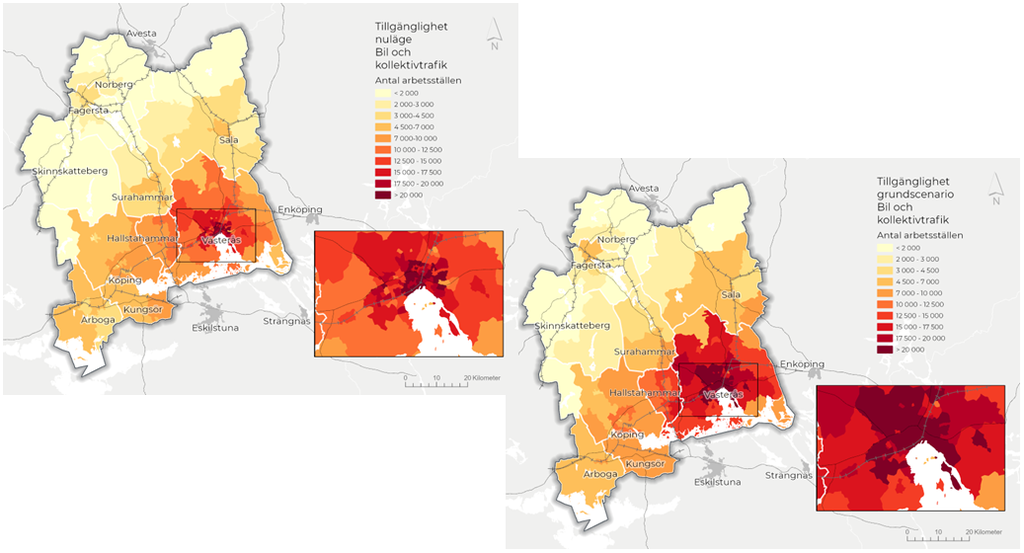

Tillgänglighet år 2022 respektive i utblick utifrån grundscenario i Länstranssportplan

I studien påvisas också hur förbättringen i tillgänglighet påverkar Tobins q i de områden där förändringen sker. Genom en förbättrad tillgänglighet möjliggörs en mer attraktiv bostadsmarknad.

## Matchning och kompetensförsörjning

Matchningsproblematiken lyfts ofta fram som en av arbetsmarknadens största utmaningar. Parallellt finns lediga jobb som det är svårt att tillsätta och ett relativt stort antal människor som har långvariga svårigheter att finna en sysselsättning. En annan del av matchningsproblematiken är att belysa i vilken utsträckning människor jobbar med det de är utbildade för och, kanske framför allt, om det är så att de *inte* återfinns inom ett yrke de är utbildade för.

### Befolkningens utbildning

Befolkningens utbildningsnivå höjs successivt. År 2022 hade var tredje person i åldern 20-64 år kortare utbildning än treårigt gymnasium som högsta avslutade utbildning. År 2007 var andelen 47 procent. Den viktigaste anledningen till detta är att den äldre befolkningen (som vanligen har lägre högsta avslutad utbildning än yngre generationer) fasas ur de arbetsföra åldrarna. Den grupp som ökar mest är personer med minst treårig eftergymnasial utbildning, som motsvarade 16 procent av befolkningen år 2007 och 23 procent år 2022. Gruppen med kortare eftergymnasial utbildning är i princip oförändrad, andelen motsvarade 14 procent år 2007 och 15 procent år 2022. Andelen med gymnasieutbildning som högsta avslutad nivå har ökat från 23 procent år 2007 till 28 procent år 2022. Inom gruppen ser vi störst tillväxt bland personer med yrkesförberedande gymnasieutbildning.

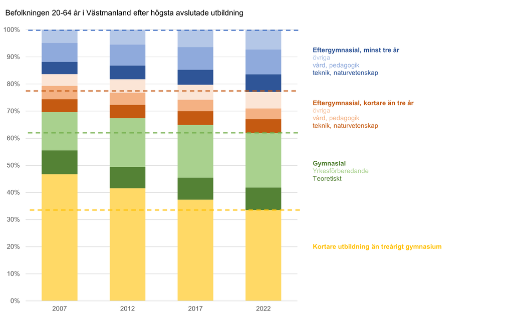

Källa: SCB

### Matchningsgrad bland sysselsatta

Matchningsgrad visar andelen anställda som arbetar i yrken som stämmer väl överens med deras utbildning. För att detta ska gälla ska det dels finnas en stark överensstämmelse mellan utbildningens och yrkets ämnesinriktning (t.ex. teknikutbildning – teknikyrke) och dels ska utbildningsnivån vara rätt i förhållande till vad yrket kräver. Här accepteras även en lägre utbildningsnivå än vad yrket normalt kräver, eftersom matchningsproblematiken på arbetsmarknaden i första hand brukar avse ”överutbildning” och inte ”underutbildning”. Dessutom kan en individ ha fått den kompetens som yrket kräver genom yrkeserfarenhet eller på annat sätt än genom formell utbildning.

I Västmanland arbetar 72 procent av samtliga sysselsatta inom ett yrke som motsvarar deras utbildning. Det är något högre än riksgenomsnittet även om nivåerna ligger ganska nära varandra. Matchningsgraden är högre för kvinnor än för män, 73 procent jämfört med 70 procent, vilket är i nivå med skillnaderna mellan könen i riket.

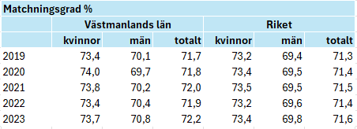

Utöver matchningsgraden hos de sysselsatta är det möjligt att studera den matchade förvärvsgraden för olika utbildningsinriktningar. Här jämförs alltså den totala förvärvsgraden för personer med respektive utbildning med personer med matchad förvärvsfrekvens, det vill säga deras utbildning matchar helt deras yrke. Diagrammet kan läsas som att mellanskillnaden mellan staplarna inom respektive utbildning utgörs av personer som är sysselsatta men inte har fullständig matchning mot sin utbildning. Ett exempel kan vara en person som är utbildad till lärare och är verksam inom någon helt annan bransch. Som diagrammet visar har dock pedagogik och lärarutbildning den enskilt högsta matchade förvärvsfrekvensen, 72 procent. Därefter följer hälso & sjukvård och social omsorg med 68 procent. Eftersom detta är kvinnodominerade utbildningar och yrken ger det också förklaringen till att kvinnor har en högre matchningsgrad än män, som vi såg i den inledande tabellen.

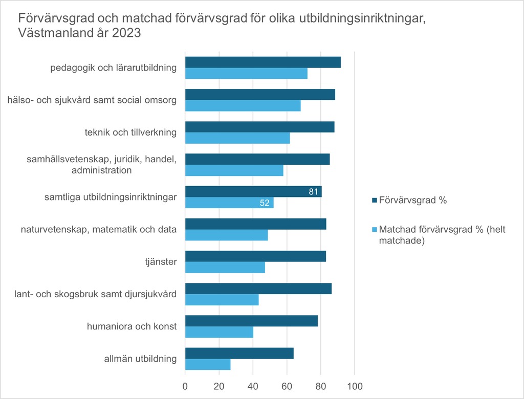

## Arbetsmarknadens struktur

Enligt den senaste preliminära statistiken ur Befolkningens arbetsmarknadsstatus (BAS) fanns drygt 125 000 sysselsatta personer med arbetsplats i länet i slutet av 2023. Vi har grupperat de sysselsatta i fem olika geografiska områden: Fagersta, Norberg och Skinnskatteberg (FNS); Köping, Arboga och Kungsör (KAK); Surahammar och Hallstahammar (SH) samt Sala respektive Västerås. Därefter har vi tittat på hur stor andel inom respektive områdena som återfinns i de olika näringsgrenarna, som i sin tur är sorterade i fallande ordning efter hur många de sysselsätter totalt i länet. Det gör att färgskalan för länet totalt blir perfekt graderad från störst till minst, mörkt grön till mörkt röd. I kolumnerna för de olika områdena indikerar ett annorlunda färgmönster en avvikande näringsgrensstruktur från hela länet. Det kanske tydligaste exemplet på detta är sysselsatta inom tillverkningsindustrin, där andelen går från 33 procent i FNS till 9 procent i Sala. I Västerås är andelen sysselsatta inom tillverkningen 13 procent samtidigt som man har den högsta andelen i länet inom juridik, ekonomi, teknik (som ibland kallas avancerade företagstjänster), 16 procent.

De näringsgrenar som är mer kopplade till befolkningen och är likartade i länet, är främst vård & omsorg och utbildning, där andelen sysselsatta är snarlika oavsett länsdel. Vi ser också att Sala sticker ut genom högst andel sysselsatta inom byggindustri, 12 procent mot länets genomsnitt på 7 procent.

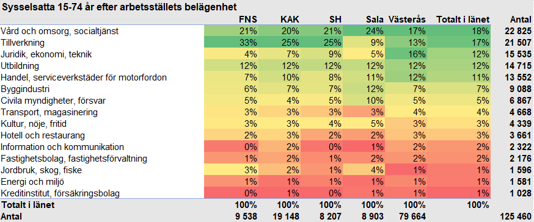

De näringsgrenar i länet som sysselsätter flest med högre utbildning är civila myndigheter, utbildning och information & kommunikation där över 60 procent av de sysselsatta har någon form av eftergymnasial utbildning. Inom utbildningsväsendet har hälften av de sysselsatta eftergymnasial utbildning längre än tre år. Omvänt så är de näringsgrenar där största andel av de sysselsatta har högst gymnasial utbildning (cirka 80 procent av de sysselsatta) byggindustri, hotell & restaurang och transport & magasinering.

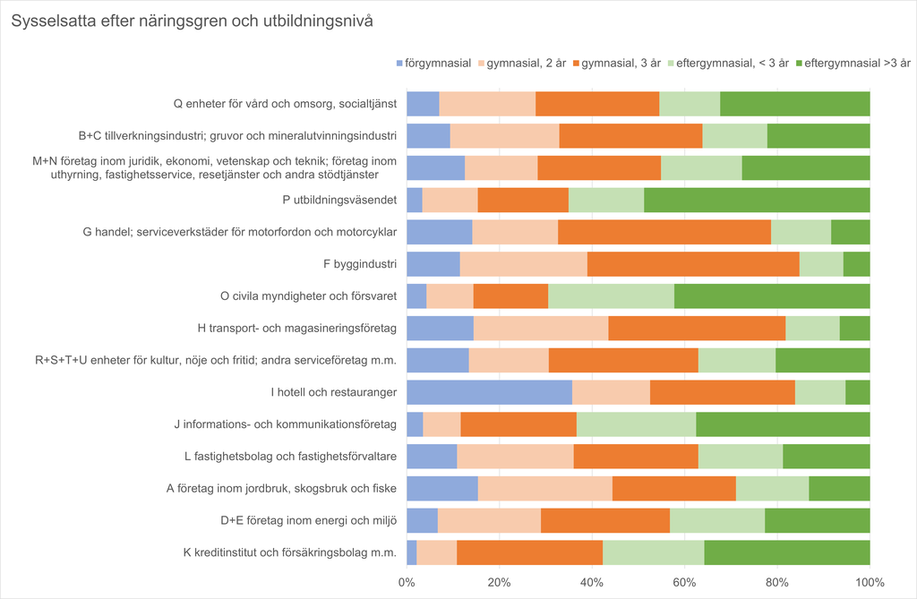

### Specialisering

Specialisering är ett sätt att mäta hur vanligt förekommande en specifik näringsgren är inom ett område i relation till hur det ser ut nationellt. Enkelt uttryckt mäts andelen sysselsatta i Västmanlands län inom en näringsgren dividerat med andelen sysselsatta i riket i samma näringsgren. En kvot över 1 innebär att näringsgrenen sysselsätter fler i länet relativt sett än nationellt. Här kan vi se ganska tydliga mönster att de näringsgrenar som till stor del är beroende av folkmängdens storlek kommer att vara ungefär lika stora på alla platser, t.ex. utbildning, hälso-och sjukvård, handel och fastighetsverksamhet. Det som blir allra mest intressant är naturligtvis de områden där Västmanland har en hög specialiseringskvot men det kan även vara intressant att se inom vilka branscher kvoten är låg och vad som ligger bakom detta.

I tabellen nedan ses de näringsgrenar i Västmanland som har högst specialiseringskvot och hur stor andel av sysselsättningen i riket de står för. Observera att vi här tittar på en finare näringsgrensindelning än tidigare i rapporten, vilket är nödvändigt för att få en tydligare bild av specialiseringen.

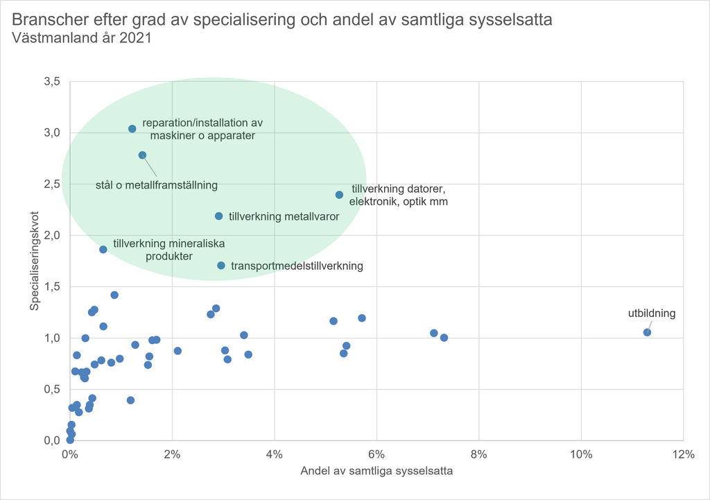

Att en näringsgren har en hög grad av specialisering betyder inte att den har stor betydelse för sysselsättningen i länet, som figuren visar finns det några näringsgrenar med hög specialiseringsgrad och relativt liten andel sysselsatta. Några av näringsgrenarna tillhör dock även de som är viktigast för sysselsättningen totalt sett, som tillverkning av datorer, elektronikvaror, optik, elappparatur och andra maskiner och apparater, transportsportmedelstillverkning och metallvarutillverkning. Här finns flera av de större företag som länge drivit på utvecklingen i länet.

För att ytterligare sätta specialiseringsgraden i kontext har vi tittat på den i kombination med sysselsättningsutvecklingen under perioden 2016-2021. I diagrammet ses specialiseringsgraden på den horisontella axeln, där ett värde på 2 innebär att branschen är dubbelt så vanlig i länet som i riket. På den vertikala axeln visas sysselsättningsförändringen mellan åren 2016 och 2021 i procent för branscher med fler än 1 000 sysselsatta i Västmanland. Bland branscher med hög specialisering är det endast en som haft en positiv utveckling av antalet sysselsatta, reparationer och installationer av maskiner och apparater, övriga ligger runt noll eller under (negativ sysselsättningsutveckling). Kopplat till tillväxt blir det tydligt att det inte är genom ökad sysselsättning som de här branscherna bidrar till BRP:s utveckling, utan genom ökad produktivitet.

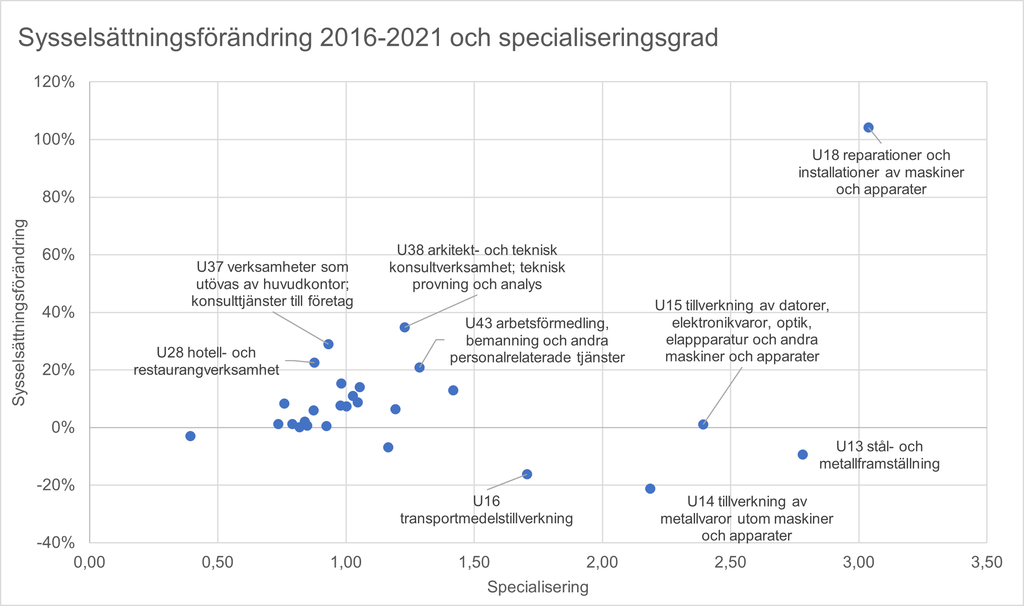

Diagrammet visar endast branscher med fler än 1 000 sysselsatta år 2021

### Shift-shareanalys av branschstrukturen i länet

Shift-shareanalys är ytterligare en metod som kan användas för att dels få en översiktlig bild av hur branschstrukturen i länet och dess kommuner ser ut och dels för att se hur enskilda branscher presterat över en viss tidsperiod.

**Kort om metoden:**

Resultatet från en shift-share innehåller fyra delar eller komponenter:

**Branschkomponenten** visar hur många jobb som en bransch förväntas växa eller krympa med i länet, baserat på hur branschens jobbtillväxt sett ut i riket. Är siffran negativ betyder det att branschen underpresterar i förhållande till ekonomin som helhet. Om den samlade branschkomponenten för alla branscher i ett län är negativ, betyder det att länet har en tyngd mot krympande branscher – en ofördelaktig branschstruktur.

Den **nationella komponenten** visar hur många jobb som en bransch förväntas växa med till följd av den generella konjunkturutvecklingen i landet. Om exempelvis den totala jobbtillväxten i riket varit 10 procent, väntas alla branscher i länet få ett positivt tillskott på 10 procent. En god ekonomisk utveckling kan med andra ord hindra en negativ utveckling inom en annars krympande bransch.

Den **förväntade utvecklingen** är summan av den nationella komponenten och branschkomponenten. Siffran visar hur mycket vi kan förvänta oss att en bransch ska ha växt i länet under en given tidsperiod, baserat på konjunkturens utveckling och den branschspecifika utvecklingen i riket under samma period. Den summerade förväntade utvecklingen för alla branscher visar hur stor jobbtillväxten förväntats vara i länet som helhet under den studerade tidsperioden.

Den **regionala prestationen** är differensen mellan den faktiska utvecklingen och den förväntade utvecklingen. Om den regionala prestationen är positiv för en bransch betyder det att branschen går starkare i det egna området än i riket som helhet, vilket är en indikation på att det finns konkurrensfördelar i regionen för denna bransch. Om den regionala prestationen för länet som helhet är positiv, betyder det att länet överpresterar jämfört med riket, sett till sin branschstruktur.

Vi har tittat på perioden 2011-2021 i analysen. Det finns senare helårsdata, men eftersom den baseras på befolkningens arbetsmarknadsstatus (BAS) som bara finns tillgänglig från år 2020 valde vi att här utgå ifrån den tidigare registerbaserade arbetsmarknadsstatistiken.

Förändringen av antalet sysselsatta i Västmanland visas nedan per bransch utifrån branschkomponenten, den förväntade utvecklingen (nationell komponent + branschkomponent) och den faktiska utvecklingen under perioden 2011-2021. Inom fem branscher har länet haft en sysselsättningsutveckling som överstiger den förväntade: hotell o restaurang, fastighet, företagstjänster, utbildning samt vård o omsorg. De två branscher som sticker ut mest strukturmässigt är information o kommunikation samt finans o försäkring. Här har utvecklingen i länet gått åt helt motsatt håll jämfört med den förväntade utvecklingen. Vi ser även att branscherna tillverkning respektive jord o skogsbruk är de enda med en förväntad negativ utveckling och där följer länet det nationella mönstret.

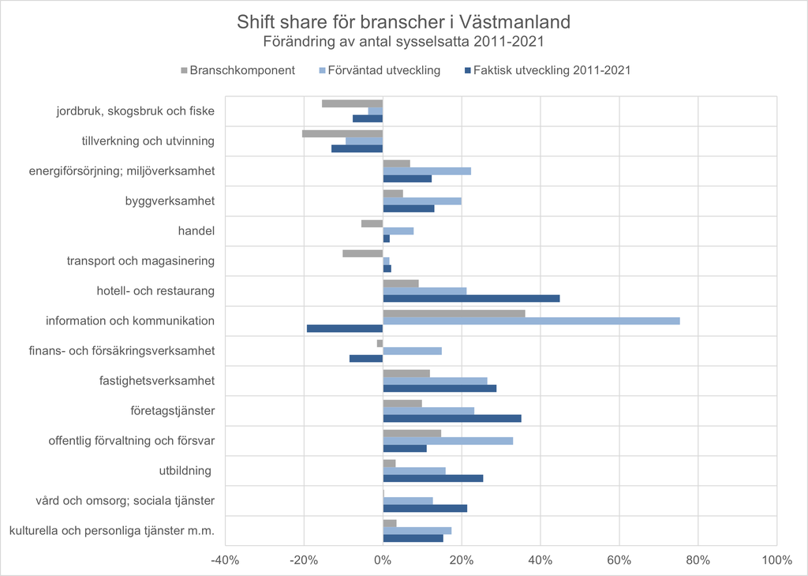

Källa: SCB, egna beräkningar

Om alla branscher i ett område summeras i samband med analysen så ger utfallet för branschkomponenten en indikation på hur branschfördelningen i området ser ut. Om utfallet är negativt finns en tyngdpunkt mot branscher där sysselsättningen utvecklas negativt. I bilden nedan visas det summerade resultatet för alla branscher i respektive kommun efter branschkomponent samt förväntad och faktisk utveckling. Översiktligt visar bilden att branschstrukturen i Skinnskatteberg, Surahammar och Fagersta har en tonvikt på branscher som backar sett till sysselsättningen. Dock ser vi direkt att Skinnskatteberg är den kommun i länet som “överpresterar” mest. Den faktiska sysselsättningen ökade med 11 procent under perioden, jämfört med förväntade fyra procent. I en jämförelse ser vi att Surahammar har en liknande branschkomponent som Skinnskatteberg, något högre förväntad utveckling (som alltså baseras på den nationella övergripande tillväxten och branschkomponenten) och en faktisk utveckling som varit negativ (-8%). I Surahammar verkar därför branschkomponenten väga tyngre än i Skinnskatteberg, kommunen har inte kunnat hålla jämna steg med den nationella tillväxttakten. Skinnskatteberg är en mindre kommun än Surahammar vilket kan påverka procentsiffrorna, men tittar vi på enskilda branscher i kommunerna ser vi att den största skillnaden är att i Surahammar har en regional prestation som är negativ eller svagt positiv bland de branscher som sysselsätter flest personer, metall- och tillverkningsindustri. I Skinnskatteberg har man haft den allra mest positiva regionala prestationen inom tillverkningsindustrin, som även den bransch som sysselsätter flest människor i kommunen. Detta visar med andra ord på betydelsen av att ha ett framgångsrikt företag som Systemair i kommunen, samtidigt som det också kan ses som en potentiell risk.

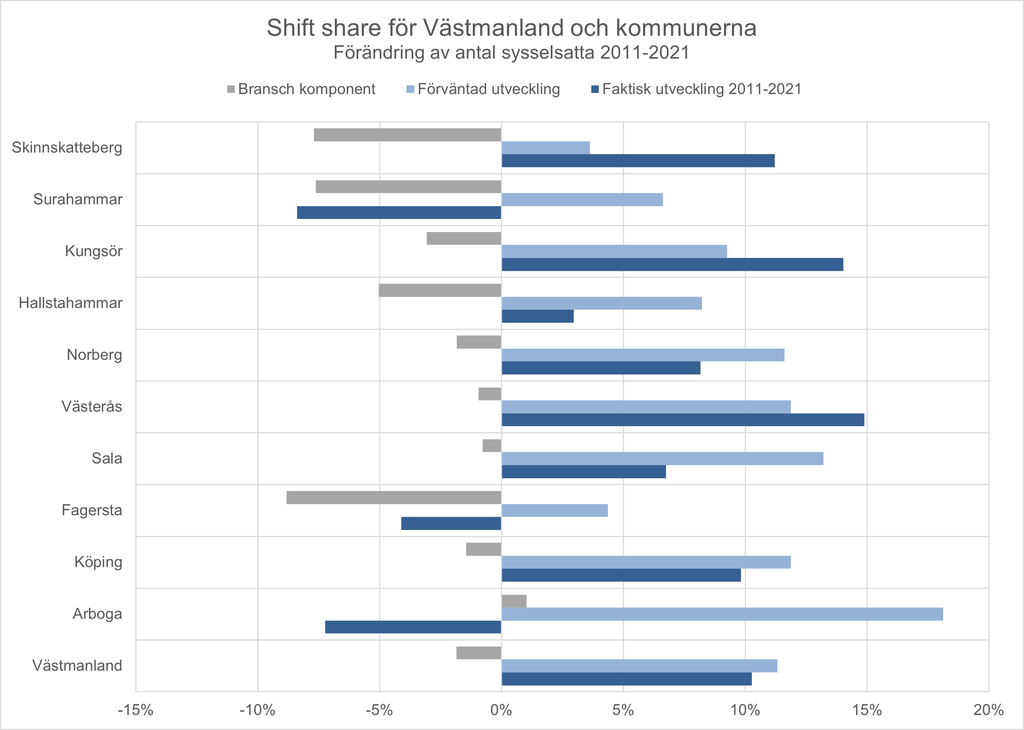

Källa: SCB, egna beräkningar

En annan kommun som sticker ut i länet är Arboga, som är den enda kommunen med en positiv branschkomponent. Här finns alltså en branschstruktur med mer gynnsamma förutsättningar för sysselsättningsökningar. I kombination med den nationella ökningstakten ger det att kommunen har den högsta förväntade utvecklingen bland länets kommuner. Som diagrammet visar var dock den faktiska sysselsättningsutvecklingen i Arboga negativ under den här perioden, vilket till stor del kan härledas till stora neddragningar inom försvars- och transportindustrin.

Slutligen ska vi titta på samma bild som tidigare, men för länen inom Östra Mellansverige. Samtliga län, undantaget Uppsala, har en negativ branschkomponent (en sammansättning av branscher där sysselsättningsutvecklingen mestadels varit negativ). Den förväntade sysselsättningsökningen ligger, förenklat uttryckt, runt 12 procent i alla län. Här sticker Västmanland och Södermanland ut genom att ha en lägre sysselsättningstillväxt än förväntat, medan de tre övriga länen haft en mer positiv utveckling mellan åren 2011-2021.

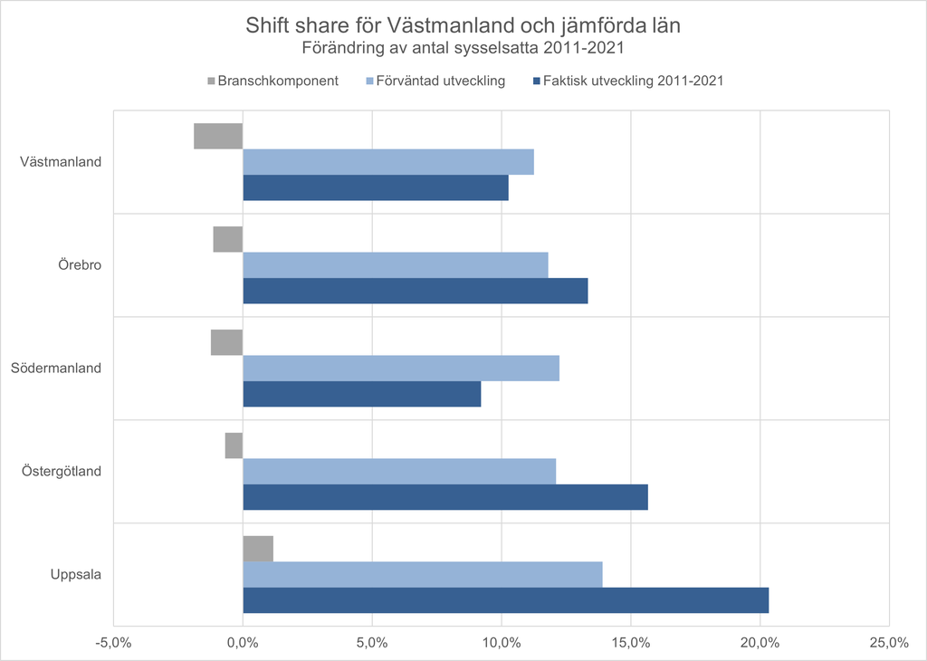

Källa: SCB, egna beräkningar

## Pendling

Pendlingsmönstren i länet ser olika ut för olika kommuner och för olika delar av befolkningen. Tre av länets kommuner har en positiv nettopendling, det är alltså fler som reser till kommunen för sitt arbete än de som bor i kommunen och arbetar på annan ort. Det är Västerås, Fagersta och Köping som i den här meningen är magneterna inom länet för fler än den egna befolkningen. Tidigare återspeglades det i att länet bestod av dessa tre lokala arbetsmarknadsregioner. Utvecklingen av pendlingsmönstren har dock inneburit att hela Västmanlands län nu räknas som en enda lokal arbetsmarknad, där Västerås är det huvudsakliga navet. Kartan nedan visar inpendlingen till alla länets kommuner från orter med fler än 20 pendlare, inklusive mellan kommunerna i Västmanland.

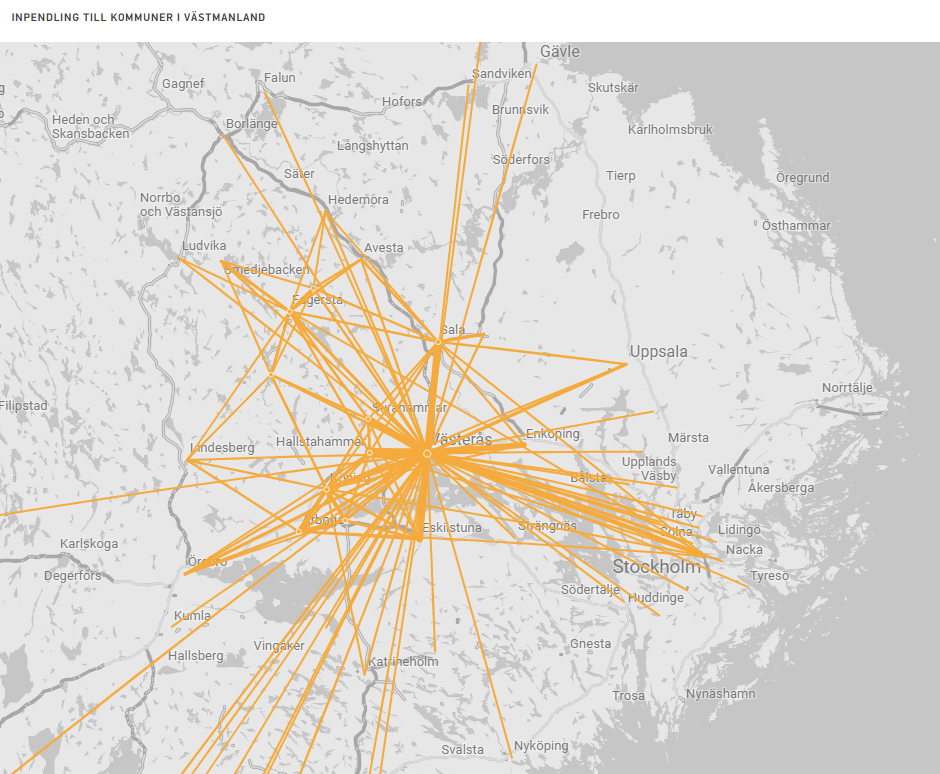

Till Fagersta pendlar huvuddelen till arbete inom tillverkningsindustrin. Kommunen har cirka 900 inpendlare och ett positivt pendlingsnetto på drygt 500 personer. Förutom tillverkningen har vård & omsorg och utbildningssektorn ett positivt pendlingsnetto på ca 100 personer vardera. Det finns inget stort utflöde från Fagersta till andra kommuner avseende pendlingsnetto, ett fåtal inom fastighetsverksamhet och företagstjänster.

Även i Köping är det främst tillverkningsindustrin som attraherar sysselsatta från andra kommuner, drygt 1 100 inpendlare och ett pendlingsnetto på ca 500 personer. Utbildning, vård & omsorg och handel är de andra branscherna med positivt pendlingsnetto. Från Köping finns ett visst utflöde i form av negativt pendlingsnetto inom företagstjänster, byggverksamhet, transport och information & kommunikation.

Bilden i Västerås är lite spretigare, störst pendlingsnetto finns inom företagstjänster, byggverksamhet och vård & omsorg. Även utbildning och tillverkning har positiva pendlingsnetton. Inom tre branscher går riktningen åt ett annat håll, med negativt pendlingsnetto: offentlig förvaltning, information & kommunikation och finans- & försäkringsverksamhet.

Den här bilden återspeglas även i grafen nedan där vi ser att Västerås, Köping och Fagersta står för en relativt sett hög andel av bidraget till länets BRP år 2021 (högre än folkmängdens andel). Tillsammans står de tre kommunerna för 80 procent av länets samlade BRP och 70 procent av befolkningen.

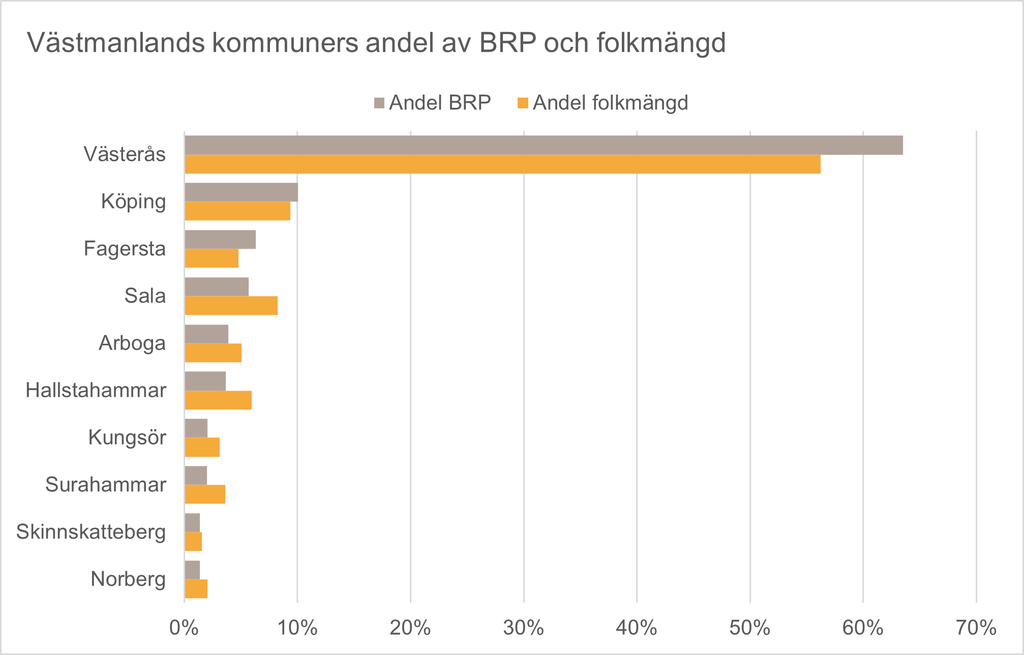

## Olika näringsgrenars utveckling och andel av BRP

Sedan början av 2000-talet har en kontinuerlig trend varit att tillverkningsindustrins bidrag till bruttoregionprodukten minskar. Det är framförallt ett resultat av att många företag renodlat sina verksamheter genom outsourcing av olika kringliggande tjänster till andra företag. Dessa återfinns vanligen inom gruppen av näringsgrenar som förenklat kallas företagstjänster. Som diagrammet nedan visar är utvecklingskurvorna i princip varandras motsats. Den sammanlagda andelen har dock inte förändrats i så hög utsträckning, från 35 procent år 2000 till 34 procent år 2022. En viktigare effekt är att den geografiska aspekten kan förändras lokalt, då många konsulter och tjänsteföretag är lokaliserade till de större städerna. I Västmanland är den typen av avancerade företagstjänster i hög grad lokaliserade till Västerås, vilket kan påverka BRP:s utveckling i länets övriga kommuner, om verksamheten tidigare funnits i den egna kommunen. På samma sätt kan BRP för länet påverkas om verksamheter som tidigare funnits i t.ex. Västerås nu utgår ifrån Stockholm, andra delar av landet eller internationellt.

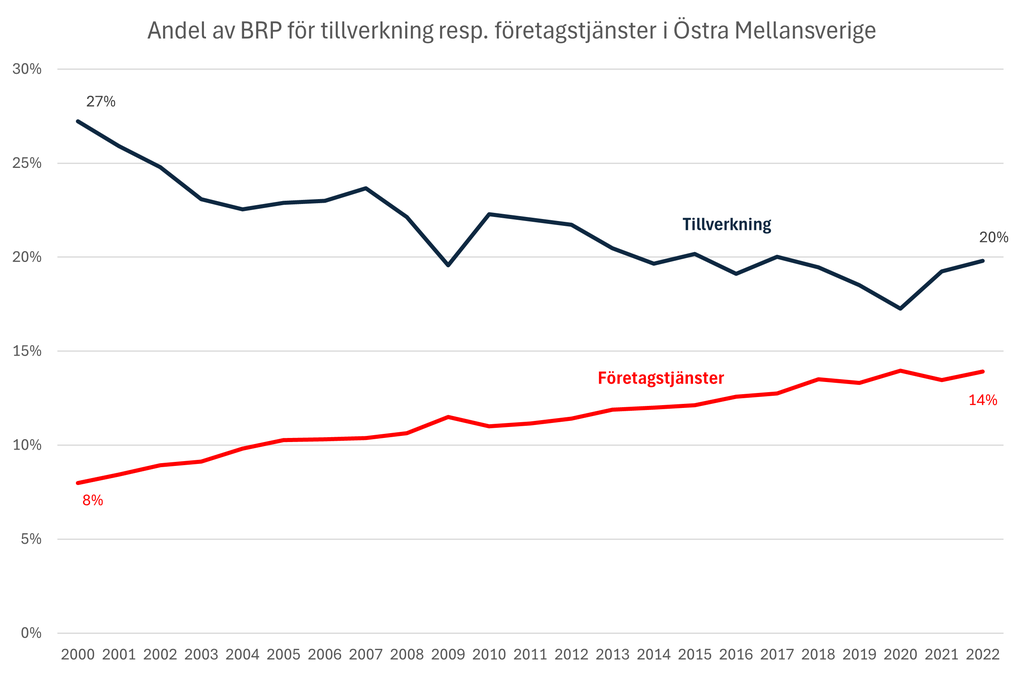

Källa: SCB

## Kontakt med omvärlden

### Internationaliseringsindex

Tillväxtverkets regionala internationaliseringsindex illustrerar hur internationellt integrerade landets län är sett till handel, näringsliv, arbetsmarknad och turism. Indexet delas upp i tre delar, där **handeln** återspeglar varu- och tjänsteexport per capita. **Arbetsmarknad och näringsliv** innehåller andel utländska arbetsställen och anställda vid dessa samt andel exporterande små och medelstora företag. **Turism** innehåller antal utländska gästnätter per capita. Totalindexets fördelning motsvarar 50 % handel, 40 % arbetsmarknad och näringsliv och 10 % turism.

Totalindex har sjunkit för länet sedan mitten av 2010-talet, både utifrån faktorerna handel och arbetsmarknad och näringsliv. Index för den senare steg vid senaste mättillfället, men ligger fortfarande lågt i relation till tidigare högsta notering.

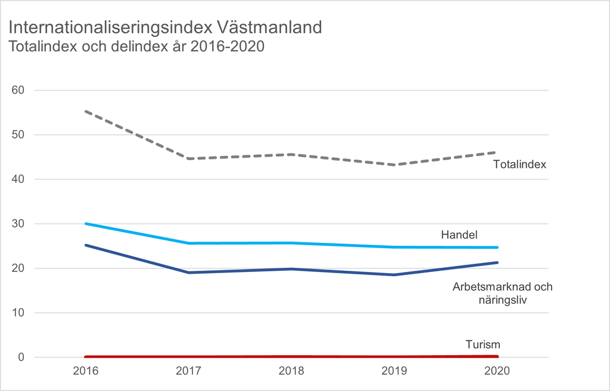

### Exporterande företag

År 2023 exporterade västmanländska företag varor till ett värde av drygt 48 miljarder kronor. År 2021 är det senaste värdet med uppgifter på kommunnivå och då kom ungefär hälften av värdet från företag i Västerås, 20 procent från företag i Köping och 16 procent från företag i Fagersta. Övriga kommuner stod för totalt 18 procent av länets exportvärde (mellan 1-5 procent vardera).

Import- och exportvärdets utveckling för varor under 2000-talet visas för Västmanland och riket i diagrammet nedan, som en indexserie där år 2015 motsvarar 100. De prickade linjerna avser importvärden och exporten visas som heldragen linje. Den tydligaste förändringen avser importens uppgång efter 2021, som till stor del påverkats av den försvagade kronkursen. Både sett till vilka branscher i Västmanland som har störst utbyte med andra länder och vilka länder utbytet sker mot har här påverkat länet i relativt stor utsträckning. Råvaror och insatsvaror som metall och elektronik blir helt enkelt dyrare. Länet har också störst utbyte mot europeiska länder, där kronans kurs mot euron varit svag under 2020-talet.

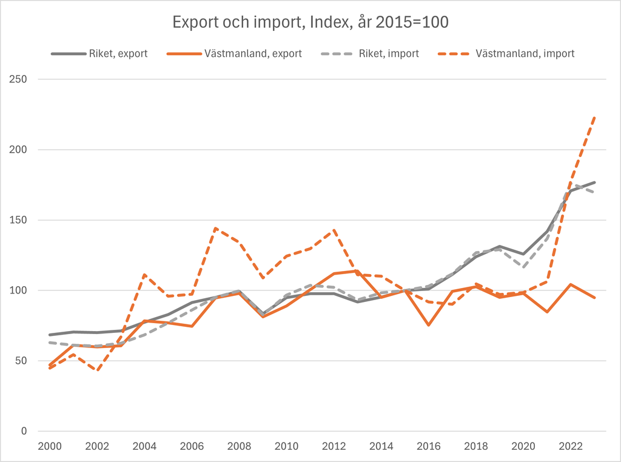

Källa: SCB

### Forskning och utveckling

I Västmanland spenderades drygt 3,7 miljarder kr i forskning och utveckling under år 2023. Det motsvarar en ökning med 28 procent jämfört med år 2021. I princip hela ökningen kan tillskrivas företagssektorn, där ökningen var 32 procent. Inom universitets- och högskolesektorn var ökningen två procent, medan offentlig sektor backade med sex procent.

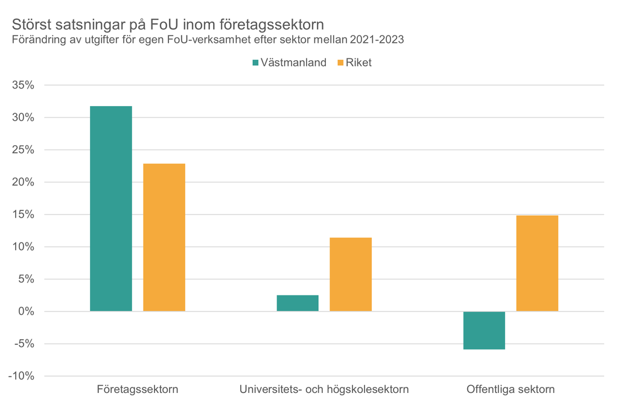

Källa: SCB

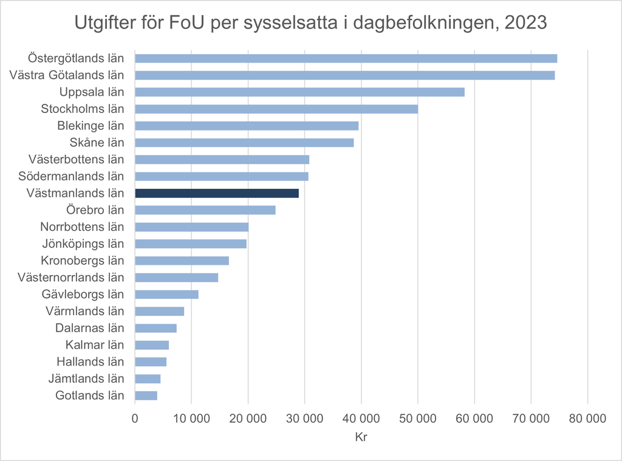

## Tillväxt i företag

### Hinder för tillväxt

Tillväxtverket genomför vart tredje år en enkätundersökning riktad till små och medelstora företag i Sverige. I undersökningen ställs ett antal frågor om vilka hinder för tillväxt som företagen upplever och i vilken omfattning. Det handlar om tillgång till lämplig arbetskraft, lagar och myndighetsreglers påverkan, att hitta tid för företagets kärnverksamhet, tillgång till externt ägarkapital respektive lån och krediter, kapaciteten i nuvarande lokaler samt tillgång till transportsystem.

I såväl landet som helhet som i Västmanlands län är tillgång till lämplig arbetskraft den aspekt som störst andel av företagarna ser som ett hinder för tillväxt. I länet angav var fjärde svarande (26 %) detta som ett hinder, motsvarande andel i hela landet var 32 procent. I figuren nedan visas utfallet för Västmanland vid de tre senaste tillfällena som undersökningen genomförts. Här framgår att en ännu högre andel ansåg att bristen på lämplig arbetskraft var det största tillväxthindret år 2020, då andelen var runt 40 procent. Självklart kan pandemin ha påverkat uppgången år 2020, nationellt stannade den dock vid 34 procent, vilket var en mer blygsam ökning. Synen på hur lagar och myndighetsregler påverkar tillväxtmöjligheterna har varierat, vid senaste mätningen angav 20 procent av de svarande i Västmanland att det var ett hinder. Det var en liten uppgång jämfört med 2020 men samtidigt en tydlig nedgång jämfört med år 2017, då det var den enskilda aspekt som hade allra högst andel, 26 procent.

Andelen som har angett tillgång till externt ägarkapital som ett tillväxthinder ökade vid den senaste mätningen, då 13 procent av de svarande angav detta som ett stort hinder. Även andelen som angett kapacitet i nuvarande lokaler som ett hinder har ökat, från 6 procent år 2017 till 12 procent år 2023.

Det är en relativt låg andel i Västmanland som upplever bristande tillgång till transportsystem som ett stort hinder för tillväxt, tre procent av de svarande. Nationellt var andelen 6,5 procent. Statistiken finns inte nedbruten på bransch i kombination med län, men nationellt är hotell och restaurang tillsammans med handel samt energi och vatten de branscher där högst andel angett transportsystemet som ett tillväxthinder, runt 10-12 procent.

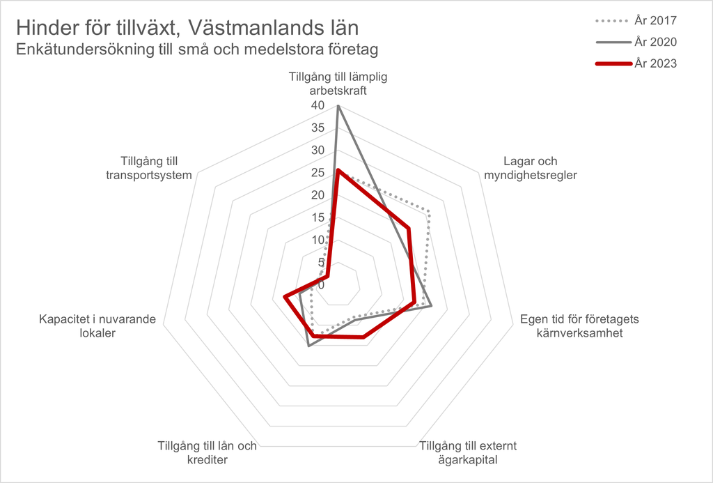

Andel % som angett respektive svarsalternativ som ett stort hinder för tillväxt i Tillväxtverkets enkätundersökning “Företagens villkor och verklighet”

## Avslutning

I rapporten har vi beskrivit utvecklingen för BRP och produktiviteten i Västmanland under den senaste tioårsperioden. Vi har även lyft ett antal olika aspekter som kan sägas utgöra grunden för ekonomisk tillväxt och verksamhet: hur den lokala arbetsmarknadens struktur ser ut, vilka demografiska och geografiska förutsättningar som finns i länet, hur länets företag finner sig tillrätta i en internationell kontext, vilka investeringar som görs sett till forskning och utveckling samt innovationer. Utöver dessa traditionella grunder för tillväxt är det också viktigt att visa på betydelsen av attraktionsförmåga hos städer och regioner, för såväl etableringar och arbetstillfällen som för inflyttning och folkökning. Attraktionsförmåga avser därmed såväl näringslivsklimat som boendemiljö och goda livsvillkor.

I anslutning till den här bakgrundsrapporten finns ytterligare en rapport, där vi har identifierat ett antal tillväxtkomponenter som offentliga aktörer på olika sätt och i skiftande utsträckning har möjlighet att påverka. Rapporten ger en nulägesbild baserat på bakgrundsrapporten och blickar även framåt kring vad som kan bli de viktigaste delarna inom de kommande tio åren. De nio tillväxtkomponenterna (utan inbördes rangordning) är:

- Infrastruktur
- Marktillgång
- Effektbehov
- Näringslivsklimat
- Stödsystem
- Varumärke
- Forskning och innovation
- Investeringar
- Kompetensförsörjning